# Assignment 01: Brush-up R and Quarto

Author

Muhammad Al Hasib

## Setup: Packages and data

```r
library(haven)
library(tidyverse)
```

```r
TEDS_2016 <- haven::read_dta("https://github.com/datageneration/home/blob/master/DataProgramming/data/TEDS_2016.dta?raw=true")
```

## Exploratory data analysis

### Data overview

```r
dim(TEDS_2016)
```

```
[1] 1690   54
```

```r
names(TEDS_2016)
```

```
 [1] "District"        "Sex"             "Age"             "Edu"
 [5] "Arear"           "Career"          "Career8"         "Ethnic"
 [9] "Party"           "PartyID"         "Tondu"           "Tondu3"
[13] "nI2"             "votetsai"        "green"           "votetsai_nm"
[17] "votetsai_all"    "Independence"    "Unification"     "sq"
[21] "Taiwanese"       "edu"             "female"          "whitecollar"
[25] "lowincome"       "income"          "income_nm"       "age"
[29] "KMT"             "DPP"             "npp"             "noparty"
[33] "pfp"             "South"           "north"           "Minnan_father"
[37] "Mainland_father" "Econ_worse"      "Inequality"      "inequality5"
[41] "econworse5"      "Govt_for_public" "pubwelf5"        "Govt_dont_care"
[45] "highincome"      "votekmt"         "votekmt_nm"      "Blue"
[49] "Green"           "No_Party"        "voteblue"        "voteblue_nm"
[53] "votedpp_1"       "votekmt_1"
```

```r
glimpse(TEDS_2016)
```

```
Rows: 1,690
Columns: 54
$ District        <dbl+lbl> 201, 201, 201, 201, 201, 201, 201, 201, 201, 201, …
$ Sex             <dbl+lbl> 2, 2, 1, 1, 2, 2, 1, 2, 2, 1, 1, 2, 2, 2, 2, 2, 2,…
$ Age             <dbl+lbl> 4, 2, 5, 4, 5, 5, 5, 4, 5, 4, 5, 1, 5, 3, 4, 5, 4,…
$ Edu             <dbl+lbl> 4, 5, 5, 2, 1, 2, 1, 5, 1, 1, 1, 2, 1, 5, 5, 1, 3,…
$ Arear           <dbl+lbl> 1, 1, 1, 1, 1, 1, 1, 1, 1, 1, 1, 1, 1, 1, 1, 1, 1,…
$ Career          <dbl+lbl> 1, 2, 1, 4, 3, 2, 4, 1, 4, 3, 3, 5, 5, 4, 1, 5, 2,…
$ Career8         <dbl+lbl> 1, 3, 1, 4, 5, 7, 4, 2, 4, 5, 5, 7, 7, 7, 2, 7, 3,…
$ Ethnic          <dbl+lbl> 1, 2, 2, 1, 9, 1, 2, 1, 1, 2, 1, 1, 2, 1, 2, 9, 2,…
$ Party           <dbl+lbl> 25, 25,  3, 25, 25,  6, 25, 24, 25, 25,  6,  5, 25…
$ PartyID         <dbl+lbl> 9, 9, 1, 9, 9, 2, 9, 6, 9, 9, 2, 2, 9, 1, 1, 9, 9,…
$ Tondu           <dbl+lbl> 3, 5, 3, 5, 9, 4, 9, 6, 9, 9, 5, 5, 9, 5, 4, 9, 9,…
$ Tondu3          <dbl+lbl> 2, 3, 2, 3, 9, 2, 9, 3, 9, 9, 3, 3, 9, 3, 2, 9, 9,…
$ nI2             <dbl+lbl>  3, 98, 98,  3, 98, 98, 98,  3, 98,  1,  2, 98, 98…
```

[output cut: 41 more lines]

```r
summary(TEDS_2016)
```

```
    District         Sex             Age           Edu            Arear
 Min.   : 201   Min.   :1.000   Min.   :1.0   Min.   :1.000   Min.   :1.000
 1st Qu.:1401   1st Qu.:1.000   1st Qu.:2.0   1st Qu.:2.000   1st Qu.:1.000
 Median :6406   Median :1.000   Median :3.0   Median :3.000   Median :3.000
 Mean   :4661   Mean   :1.486   Mean   :3.3   Mean   :3.334   Mean   :2.744
 3rd Qu.:6604   3rd Qu.:2.000   3rd Qu.:5.0   3rd Qu.:5.000   3rd Qu.:4.000
 Max.   :6806   Max.   :2.000   Max.   :5.0   Max.   :9.000   Max.   :6.000

     Career         Career8          Ethnic          Party
 Min.   :1.000   Min.   :1.000   Min.   :1.000   Min.   : 1.00
 1st Qu.:1.000   1st Qu.:2.000   1st Qu.:1.000   1st Qu.: 5.00
 Median :2.000   Median :4.000   Median :1.000   Median : 7.00
 Mean   :2.683   Mean   :3.811   Mean   :1.658   Mean   :13.02
 3rd Qu.:4.000   3rd Qu.:5.000   3rd Qu.:2.000   3rd Qu.:25.00
 Max.   :5.000   Max.   :8.000   Max.   :9.000   Max.   :26.00

    PartyID          Tondu           Tondu3           nI2
 Min.   :1.000   Min.   :1.000   Min.   :1.000   Min.   : 1.00
 1st Qu.:2.000   1st Qu.:3.000   1st Qu.:2.000   1st Qu.: 1.00
 Median :2.000   Median :4.000   Median :2.000   Median : 3.00
 Mean   :4.522   Mean   :4.127   Mean   :2.667   Mean   :35.13
 3rd Qu.:9.000   3rd Qu.:5.000   3rd Qu.:3.000   3rd Qu.:98.00
 Max.   :9.000   Max.   :9.000   Max.   :9.000   Max.   :98.00

    votetsai          green         votetsai_nm      votetsai_all
 Min.   :0.0000   Min.   :0.0000   Min.   :0.0000   Min.   :0.0000
 1st Qu.:0.0000   1st Qu.:0.0000   1st Qu.:0.0000   1st Qu.:0.0000
 Median :1.0000   Median :0.0000   Median :1.0000   Median :1.0000
 Mean   :0.6265   Mean   :0.3781   Mean   :0.6265   Mean   :0.5478
 3rd Qu.:1.0000   3rd Qu.:1.0000   3rd Qu.:1.0000   3rd Qu.:1.0000
 Max.   :1.0000   Max.   :1.0000   Max.   :1.0000   Max.   :1.0000
 NA's   :429                       NA's   :429      NA's   :248
  Independence     Unification           sq           Taiwanese
 Min.   :0.0000   Min.   :0.0000   Min.   :0.0000   Min.   :0.0000
 1st Qu.:0.0000   1st Qu.:0.0000   1st Qu.:0.0000   1st Qu.:0.0000
 Median :0.0000   Median :0.0000   Median :1.0000   Median :1.0000
 Mean   :0.2888   Mean   :0.1225   Mean   :0.5172   Mean   :0.6272
 3rd Qu.:1.0000   3rd Qu.:0.0000   3rd Qu.:1.0000   3rd Qu.:1.0000
 Max.   :1.0000   Max.   :1.0000   Max.   :1.0000   Max.   :1.0000

```

[output cut: 49 more lines]

```
 Min.   :0.0000   Min.   :0.0000   Min.   :0   Min.   :0   Min.   :0
 1st Qu.:0.0000   1st Qu.:0.0000   1st Qu.:0   1st Qu.:0   1st Qu.:0
 Median :0.0000   Median :0.0000   Median :0   Median :0   Median :0
 Mean   :0.2053   Mean   :0.2752   Mean   :0   Mean   :0   Mean   :0
 3rd Qu.:0.0000   3rd Qu.:1.0000   3rd Qu.:0   3rd Qu.:0   3rd Qu.:0
 Max.   :1.0000   Max.   :1.0000   Max.   :0   Max.   :0   Max.   :0
                  NA's   :429
    voteblue       voteblue_nm       votedpp_1        votekmt_1
 Min.   :0.0000   Min.   :0.0000   Min.   :0.0000   Min.   :0.0000
 1st Qu.:0.0000   1st Qu.:0.0000   1st Qu.:0.0000   1st Qu.:0.0000
 Median :0.0000   Median :0.0000   Median :1.0000   Median :0.0000
 Mean   :0.2787   Mean   :0.3735   Mean   :0.5256   Mean   :0.2309
 3rd Qu.:1.0000   3rd Qu.:1.0000   3rd Qu.:1.0000   3rd Qu.:0.0000
 Max.   :1.0000   Max.   :1.0000   Max.   :1.0000   Max.   :1.0000
                  NA's   :429      NA's   :187      NA's   :187
```

## Problems encountered when working with the dataset

Several issues arise when working with the TEDS 2016 dataset:

```r
# Check missing values across all variables
TEDS_2016 %>%
  summarise(across(everything(), ~sum(is.na(.)))) %>%
  pivot_longer(everything(),
               names_to = "variable",
               values_to = "n_missing") %>%
  filter(n_missing > 0) %>%
  arrange(desc(n_missing))
```

```
# A tibble: 10 × 2
   variable     n_missing
   <chr>            <int>
 1 votetsai           429
 2 votetsai_nm        429
 3 votekmt_nm         429
 4 voteblue_nm        429
 5 income_nm          330
 6 highincome         330
 7 votetsai_all       248
 8 votedpp_1          187
 9 votekmt_1          187
10 edu                 10
```

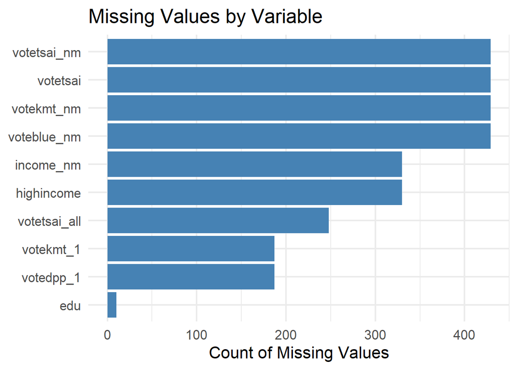

```r
# Visualize missing values
TEDS_2016 %>%
  summarise(across(everything(), ~sum(is.na(.)))) %>%
  pivot_longer(everything(),
               names_to = "variable",
               values_to = "n_missing") %>%
  filter(n_missing > 0) %>%
  ggplot(aes(x = reorder(variable, n_missing), y = n_missing)) +
  geom_col(fill = "steelblue") +
  coord_flip() +
  labs(title = "Missing Values by Variable",
       x = NULL, y = "Count of Missing Values") +
  theme_minimal(base_size = 16)
```

## Deal with missing values

There are several strategies for handling missing values depending on context:

- **Listwise deletion (`drop_na()`):** Remove all rows with any missing values. Simple but can reduce sample size significantly.
- **Variable-wise filtering:** Remove only rows where the specific variable of interest is missing, preserving more data for other analyses.
- **Imputation:** Replace missing values with the mean, median, or mode for numeric variables, or use multiple imputation for more rigorous analysis.
- **Flagging:** Create a binary indicator variable to flag whether a value was missing, which can itself be informative in modeling.

For this analysis, listwise deletion is used for modeling tasks, while missing values are retained for descriptive summaries.

```r
# Example: drop rows missing votetsai and key predictors
teds_clean <- TEDS_2016 %>%
  dplyr::select(votetsai, Tondu, female, DPP, age, income, edu, Taiwanese, Econ_worse) %>%
  drop_na()

cat("Rows after dropping missing values:", nrow(teds_clean), "\n")
```

```
Rows after dropping missing values: 1257
```

```r
cat("Rows removed:", nrow(TEDS_2016) - nrow(teds_clean), "\n")
```

```
Rows removed: 433
```

## Exploring the relationship between tondu and other variables

To explore the relationship between `Tondu` (unification-independence preference) and other variables, the following methods are appropriate:

- **Cross-tabulation / frequency tables** for categorical variables (e.g., Tondu vs. female, DPP)
- **Boxplots or violin plots** for continuous variables (e.g., Tondu vs. age, income, edu)
- **Correlation analysis** for numeric relationships
- **ANOVA or chi-square tests** for inferential comparisons

```r
# Convert Tondu to factor with labels
TEDS_2016$Tondu <- factor(TEDS_2016$Tondu,
  levels = 1:7,
  labels = c("Unification now", "Status quo, unif. in future",
             "Status quo, decide later", "Status quo forever",
             "Status quo, indep. in future", "Independence now",
             "No response"))
```

### Tondu vs. Gender (female)

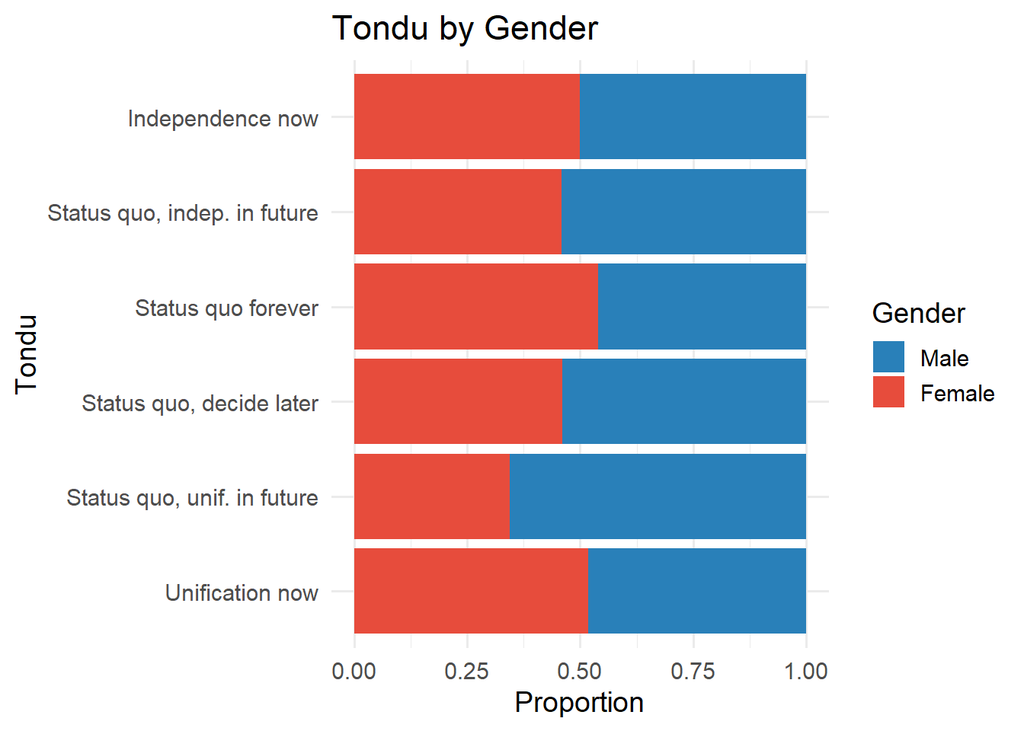

```r
TEDS_2016 %>%
  filter(!is.na(Tondu), !is.na(female)) %>%
  mutate(female = factor(female, levels = c(0, 1), labels = c("Male", "Female"))) %>%
  ggplot(aes(x = Tondu, fill = female)) +
  geom_bar(position = "fill") +
  coord_flip() +
  scale_fill_manual(values = c("Male" = "#2980b9", "Female" = "#e74c3c")) +
  labs(title = "Tondu by Gender",
       x = "Tondu", y = "Proportion", fill = "Gender") +
  theme_minimal(base_size = 14)
```

### Tondu vs. DPP Support

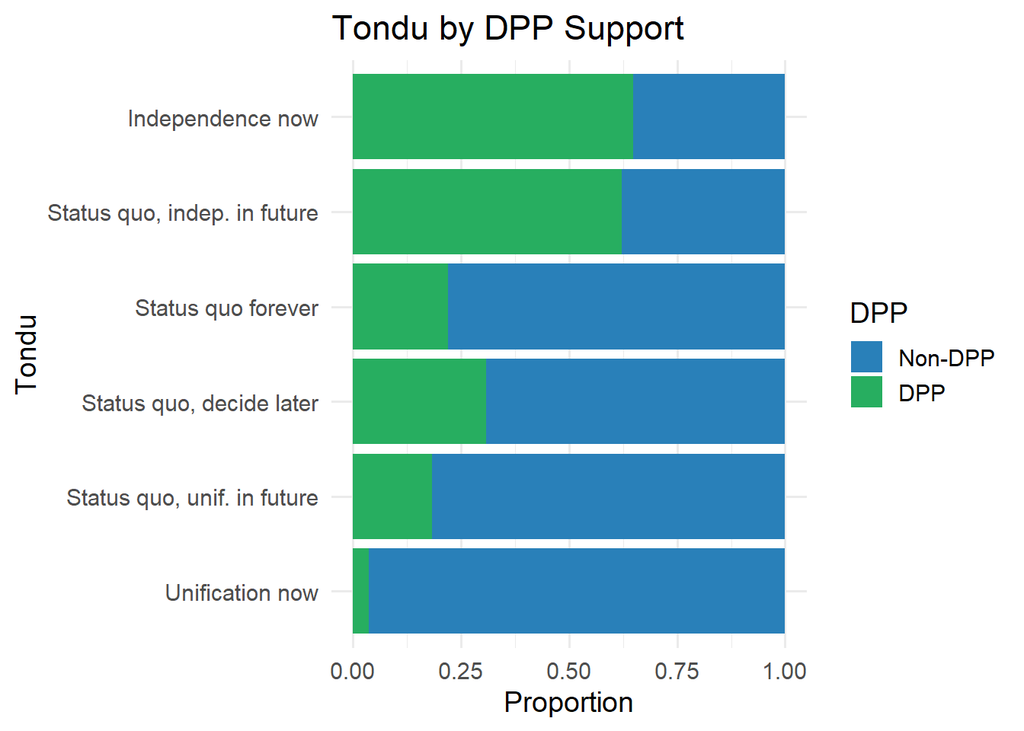

```r
TEDS_2016 %>%
  filter(!is.na(Tondu), !is.na(DPP)) %>%
  mutate(DPP = factor(DPP, levels = c(0, 1), labels = c("Non-DPP", "DPP"))) %>%
  ggplot(aes(x = Tondu, fill = DPP)) +
  geom_bar(position = "fill") +
  coord_flip() +
  scale_fill_manual(values = c("Non-DPP" = "#2980b9", "DPP" = "#27ae60")) +
  labs(title = "Tondu by DPP Support",
       x = "Tondu", y = "Proportion", fill = "DPP") +
  theme_minimal(base_size = 14)
```

### Tondu vs. Age

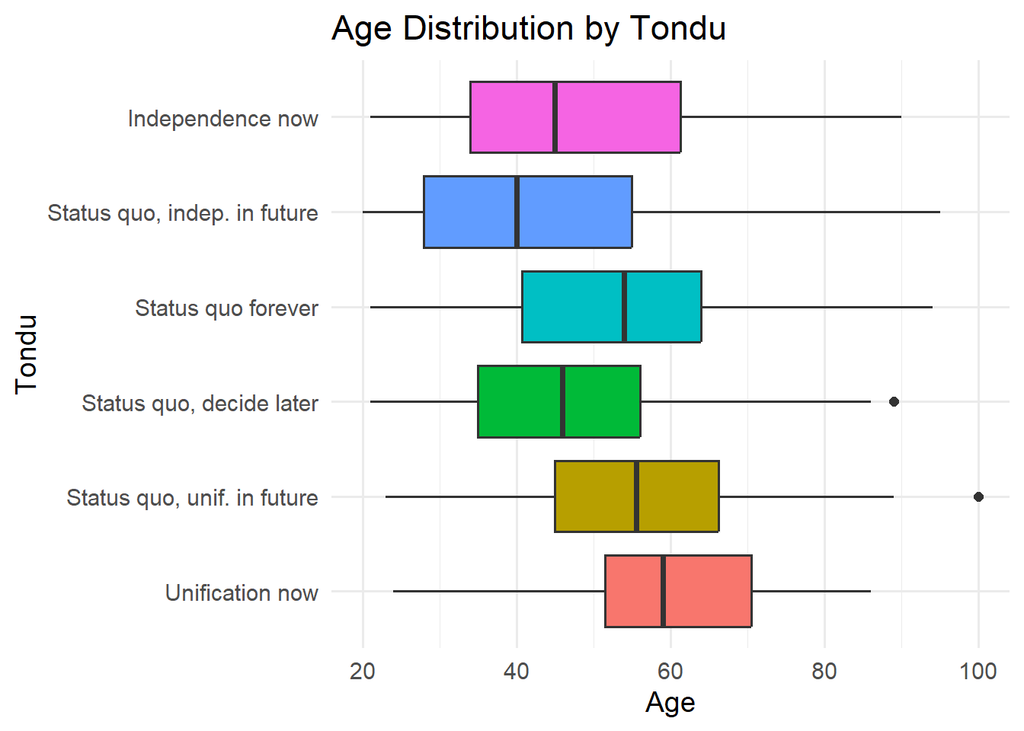

```r
TEDS_2016 %>%
  filter(!is.na(Tondu), !is.na(age)) %>%
  ggplot(aes(x = Tondu, y = age, fill = Tondu)) +
  geom_boxplot() +
  coord_flip() +
  labs(title = "Age Distribution by Tondu",
       x = "Tondu", y = "Age") +
  theme_minimal(base_size = 14) +
  theme(legend.position = "none")
```

### Tondu vs. Education

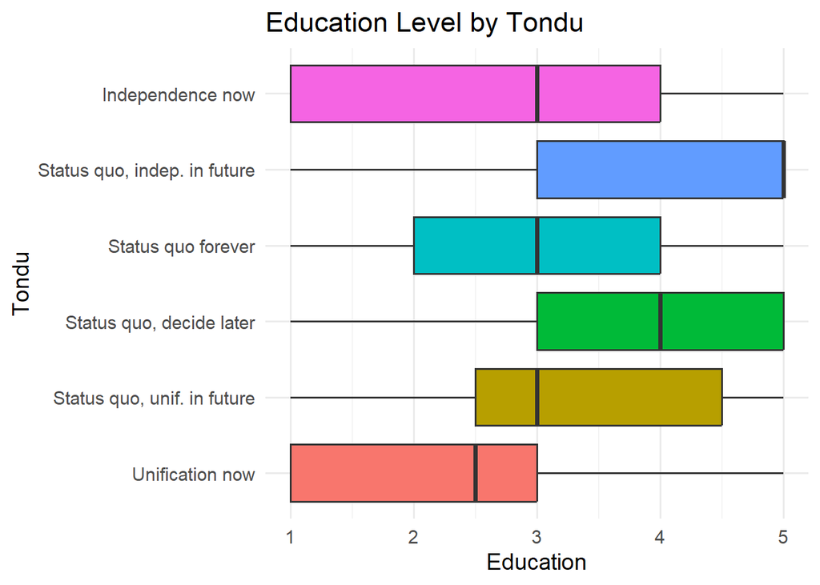

```r
TEDS_2016 %>%
  filter(!is.na(Tondu), !is.na(edu)) %>%
  ggplot(aes(x = Tondu, y = as.numeric(edu), fill = Tondu)) +
  geom_boxplot() +
  coord_flip() +
  labs(title = "Education Level by Tondu",
       x = "Tondu", y = "Education") +
  theme_minimal(base_size = 14) +
  theme(legend.position = "none")
```

### Tondu vs. Income

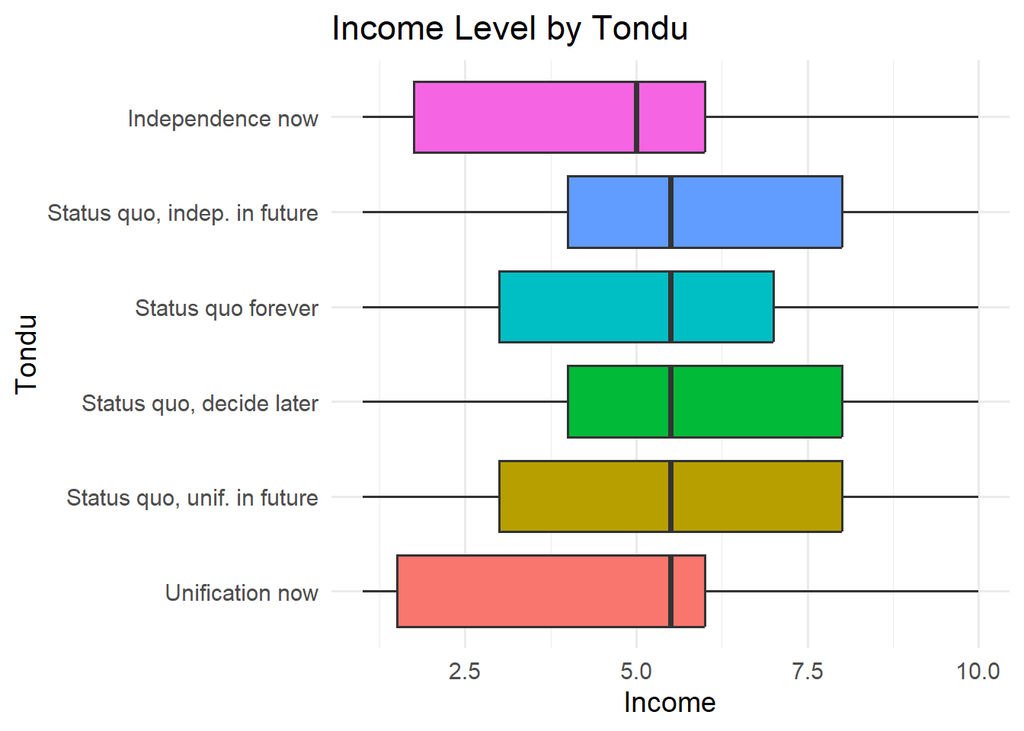

```r
TEDS_2016 %>%
  filter(!is.na(Tondu), !is.na(income)) %>%
  ggplot(aes(x = Tondu, y = as.numeric(income), fill = Tondu)) +
  geom_boxplot() +
  coord_flip() +
  labs(title = "Income Level by Tondu",
       x = "Tondu", y = "Income") +
  theme_minimal(base_size = 14) +
  theme(legend.position = "none")
```

### Tondu vs. Taiwanese Identity

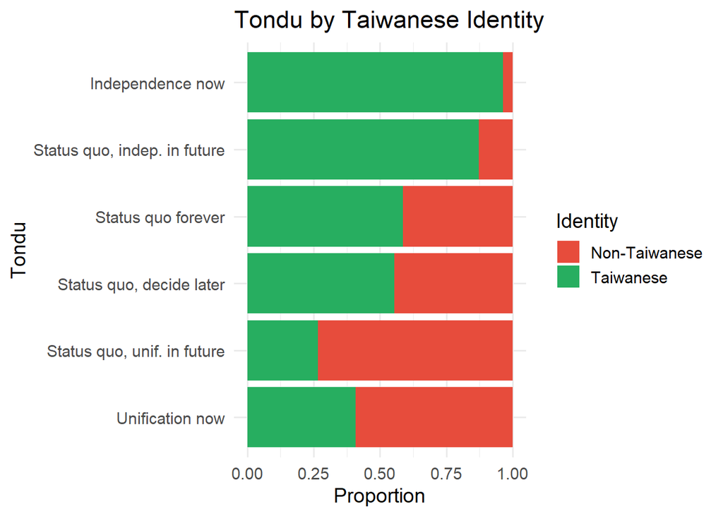

```r
TEDS_2016 %>%
  filter(!is.na(Tondu), !is.na(Taiwanese)) %>%
  mutate(Taiwanese = factor(Taiwanese, levels = c(0, 1),
                            labels = c("Non-Taiwanese", "Taiwanese"))) %>%
  ggplot(aes(x = Tondu, fill = Taiwanese)) +
  geom_bar(position = "fill") +
  coord_flip() +
  scale_fill_manual(values = c("Non-Taiwanese" = "#e74c3c", "Taiwanese" = "#27ae60")) +
  labs(title = "Tondu by Taiwanese Identity",
       x = "Tondu", y = "Proportion", fill = "Identity") +
  theme_minimal(base_size = 14)
```

### Tondu vs. Economic Pessimism (Econ_worse)

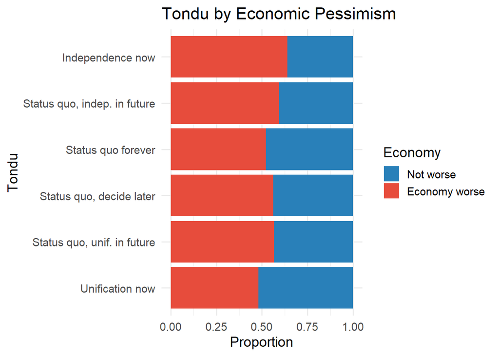

```r
TEDS_2016 %>%
  filter(!is.na(Tondu), !is.na(Econ_worse)) %>%
  mutate(Econ_worse = factor(Econ_worse, levels = c(0, 1),
                             labels = c("Not worse", "Economy worse"))) %>%
  ggplot(aes(x = Tondu, fill = Econ_worse)) +
  geom_bar(position = "fill") +
  coord_flip() +
  scale_fill_manual(values = c("Not worse" = "#2980b9", "Economy worse" = "#e74c3c")) +
  labs(title = "Tondu by Economic Pessimism",
       x = "Tondu", y = "Proportion", fill = "Economy") +
  theme_minimal(base_size = 14)
```

## The votetsai variable

The `votetsai` variable captures whether a respondent voted for DPP candidate Tsai Ing-wen (1 = Yes, 0 = No). It is a binary outcome variable, making it suitable for logistic regression rather than linear regression.

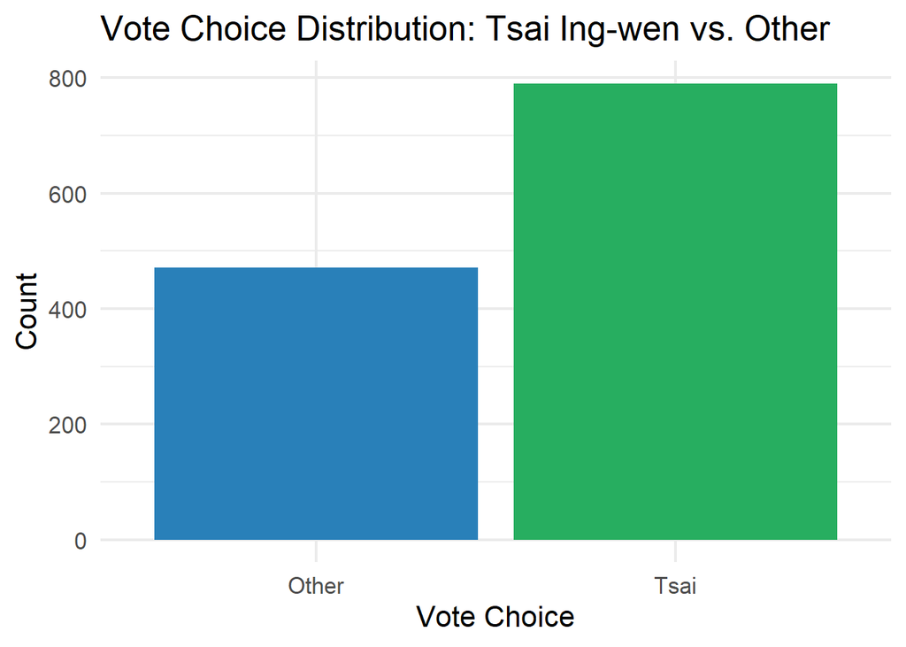

```r
# Distribution of votetsai
TEDS_2016 %>%
  filter(!is.na(votetsai)) %>%
  mutate(votetsai = factor(votetsai, levels = c(0, 1),
                           labels = c("Other", "Tsai"))) %>%
  ggplot(aes(x = votetsai, fill = votetsai)) +
  geom_bar() +
  scale_fill_manual(values = c("Other" = "#2980b9", "Tsai" = "#27ae60")) +
  labs(title = "Vote Choice Distribution: Tsai Ing-wen vs. Other",
       x = "Vote Choice", y = "Count") +
  theme_minimal(base_size = 16) +
  theme(legend.position = "none")
```

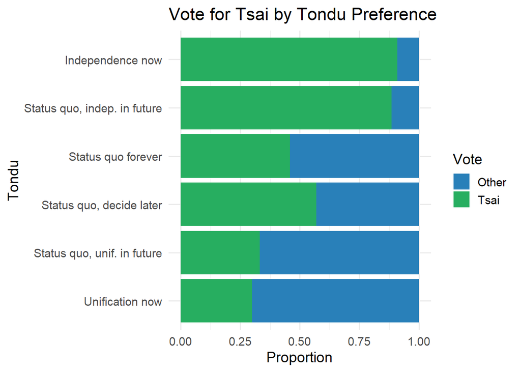

```r
# votetsai by Tondu
TEDS_2016 %>%
  filter(!is.na(votetsai), !is.na(Tondu)) %>%
  mutate(votetsai = factor(votetsai, levels = c(0, 1),
                           labels = c("Other", "Tsai"))) %>%
  ggplot(aes(x = Tondu, fill = votetsai)) +
  geom_bar(position = "fill") +
  coord_flip() +
  scale_fill_manual(values = c("Other" = "#2980b9", "Tsai" = "#27ae60")) +
  labs(title = "Vote for Tsai by Tondu Preference",
       x = "Tondu", y = "Proportion", fill = "Vote") +
  theme_minimal(base_size = 14)
```

## Frequency table and bar chart of Tondu

```r
# Frequency table
tondu_freq <- TEDS_2016 %>%
  filter(!is.na(Tondu)) %>%
  count(Tondu) %>%
  mutate(Proportion = round(n / sum(n) * 100, 1))

knitr::kable(tondu_freq,
             caption = "Frequency Table: Tondu Variable",
             col.names = c("Category", "Count", "Percentage (%)"))
```

Frequency Table: Tondu Variable

| Category | Count | Percentage (%) |
| --- | --- | --- |
| Unification now | 27 | 1.7 |
| Status quo, unif. in future | 180 | 11.5 |
| Status quo, decide later | 546 | 34.8 |
| Status quo forever | 328 | 20.9 |
| Status quo, indep. in future | 380 | 24.2 |
| Independence now | 108 | 6.9 |

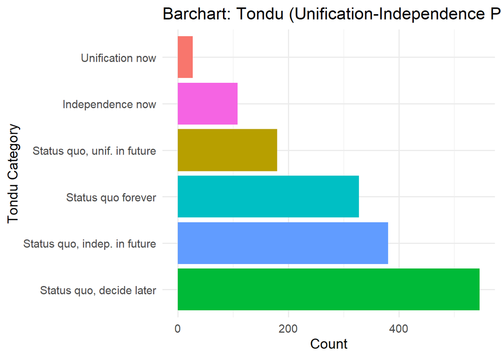

```r
# Barchart of Tondu
TEDS_2016 %>%
  filter(!is.na(Tondu)) %>%
  ggplot(aes(x = fct_infreq(Tondu), fill = Tondu)) +
  geom_bar() +
  coord_flip() +
  labs(title = "Barchart: Tondu (Unification-Independence Preference)",
       x = "Tondu Category", y = "Count") +
  theme_minimal(base_size = 14) +
  theme(legend.position = "none")
```